# Morphological phylogeny with `phangorn`

Iris Bardel-Kahr

University of Graz  
iris.bardel-kahr@uni-graz.at

Last compiled on 17 Februar, 2023

## Load packages

The package `phangorn` (Schliep 2011) (with the dependency `ape` (Paradis and Schliep 2019)) was used for this analyses (starting from a **nexus** file). If you start with a **.csv** file, `dplyr` (Wickham et al. 2022) and `tidyr` (Wickham and Girlich 2022) can be used for data manipulation.  
`set.seed` is used to get reproducible results.

```r
#install.packages("ape")
#install.packages("phangorn")

# for the latest development version, you can use:
#remotes::install_github("KlausVigo/phangorn")

#install.packages("tidyr")
#install.packages("dplyr")
library(ape)
library(phangorn)
library(tidyr)
library(dplyr)
set.seed(102)
```

## Load data

#### from a **.csv** file

```r
morpho_data <- read.csv("Matrix.csv")
```

After reading in the **.csv** file, the data has to be changed into the right format to be read as `phyDat` by `phangorn`.

```r
morpho_data$species <- gsub(" ", "_", morpho_data$species)

morpho_data <- morpho_data %>%
  mutate_if(is.numeric, as.character) %>%
  pivot_longer(cols = -species, names_to = "trait", values_to = "value") %>%
  pivot_wider(names_from = species, values_from = value) %>%
  select(-trait)
```

#### from a **.nex** (nexus) file

```r
morpho_data <- read.nexus.data("morpho_matrix_full_names.nex")
```

#### `phyDat` format for subsequent analyses

For morphometric data, `type="USER"` needs to be selected and a vector reflecting the data has to be given to `levels`. Here we have the states 0 to 8.

```r
morpho_pd <- phyDat(morpho_data, type = "USER", levels=as.character(0:8), ambiguity="?")
```

## Parsimony Trees

`pratchet` from *phangorn* uses the parsimony ratchet (Nixon 1999). `all=TRUE` gives back all possible trees with the same parsimony score. `k` (minimum number of iterations when no change in the parsimony score is detected) around **50** is sufficient for this analysis. For unordered data `method="fitch"` (the default) is much quicker and gives back the same results as `method="sankoff"`. The following `acctran` assigns branch lengths to the trees.

```r
tree_pars <- pratchet(morpho_pd, k = 50, minit = 1000,
                     maxit = 100000, all=TRUE, trace = 0)
tree_pars <- acctran(tree_pars, morpho_pd)
tree_pars
```

```
## 14 phylogenetic trees
```

There are **14** trees with lowest parsimony score.  
The outgroup is *Collohmannia johnstoni*, so we root the trees accordingly.

```r
rooted_tree <- root(tree_pars, "Collohmannia_johnstoni", resolve.root=TRUE, edgelabel=TRUE)
```

To balance out the root, we write a function and apply it to all trees in the `multiPhylo` object.

```r
pretty_root <- function(x){
  root <-  getRoot(x)
  ind <- which(x$edge[,1] == root)
  el <- sum(x$edge.length[ind]) / 2
  x$edge.length[ind] <- el
  x$node.label[1] = ""
  x
}

for (i in 1:length(rooted_tree)){
  rooted_tree[[i]] <- pretty_root(rooted_tree[[i]])
}
```

We can plot the first tree with the bootstrap values (rounded to two digits) as node labels.

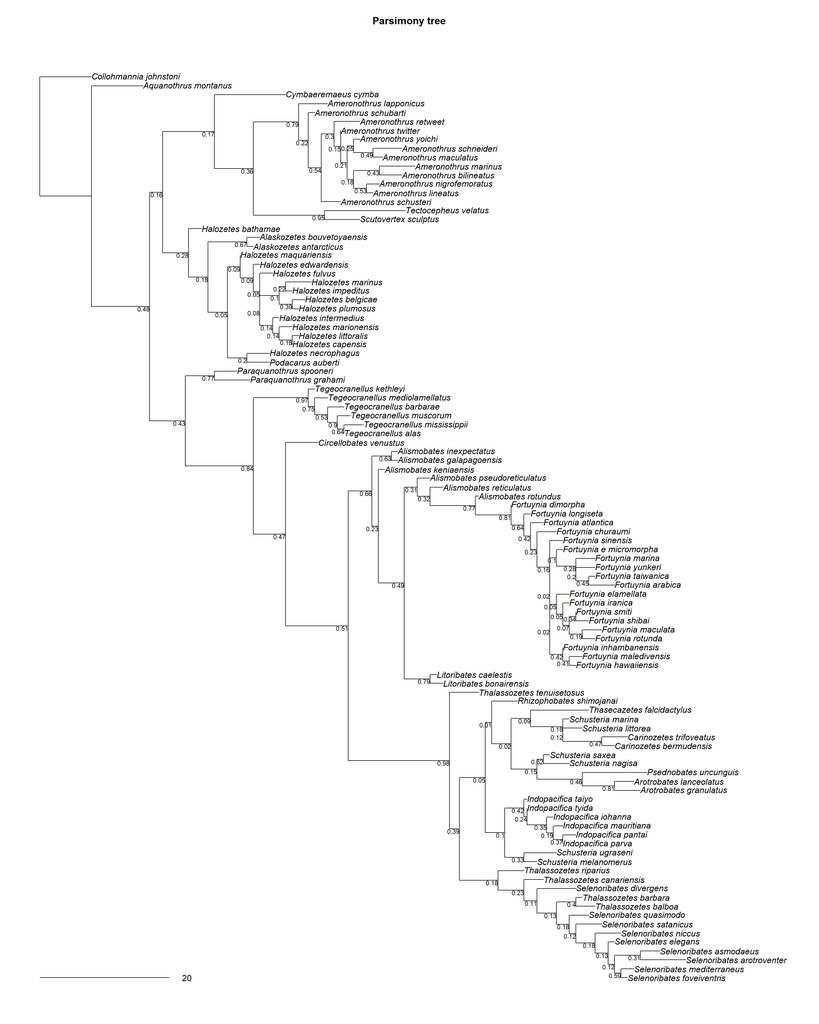

```r
par(mar = c(1,1,4,1))
plot(rooted_tree[[1]], type = "phy", edge.width=1)
title(main="Parsimony tree")
nodelabels(round(as.numeric(rooted_tree[[1]]$node.label), digits = 2), frame = "none", adj=c(1,1), cex=.75)
add.scale.bar()
```

We could also plot all trees, to get a quick overview (in this case without the node labels):

```r
par(mar = c(1,1,4,1))
plot(rooted_tree, type = "phy", cex=.5, edge.width=2)
```

For this paper, we wrote the trees in *Newick*-format to edit them in *FigTree* (Rambaut 2018). All trees can be written into one file.

```r
write.tree(tree_pars, file = "ParsimonyTrees.trees")
```